# STSCI 4630 - Spring 2019 - HW1

Da (Harry) Lu, dl947

Due Thursday, Jan/31/2019

# Question 1

> [10 points] Run lines 1 to 18, and submit the output from lines 14, 15, and 18.

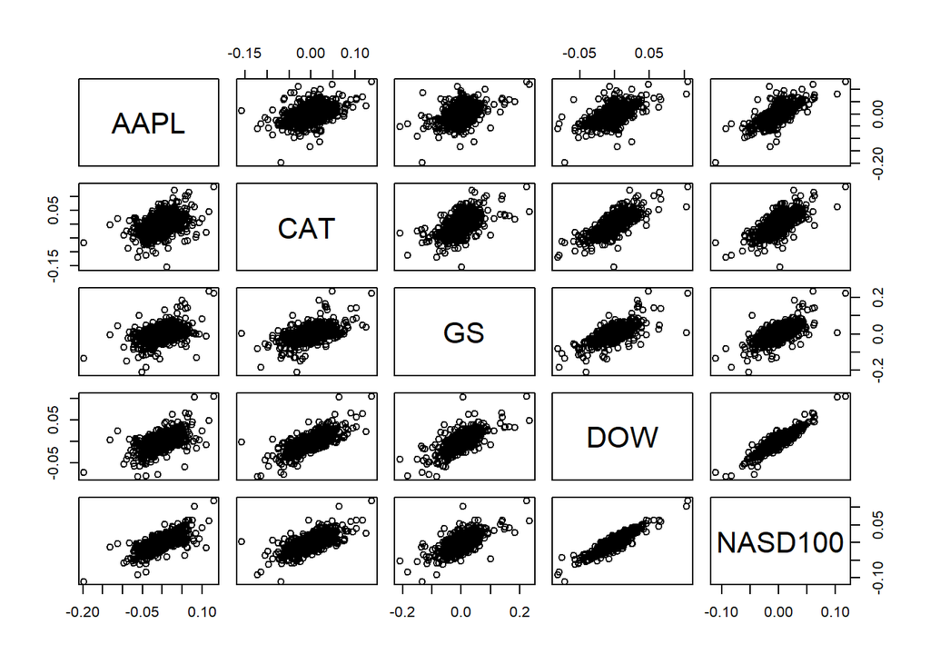

```r
plot(Returns2)
```

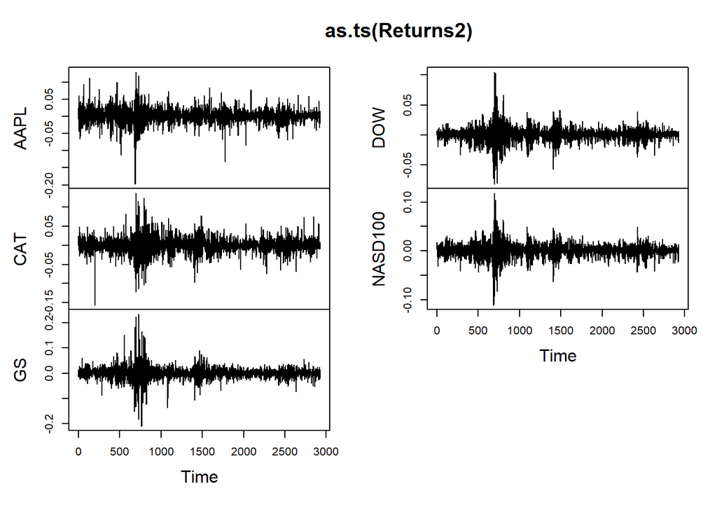

```r
plot(as.ts(Returns2))
```

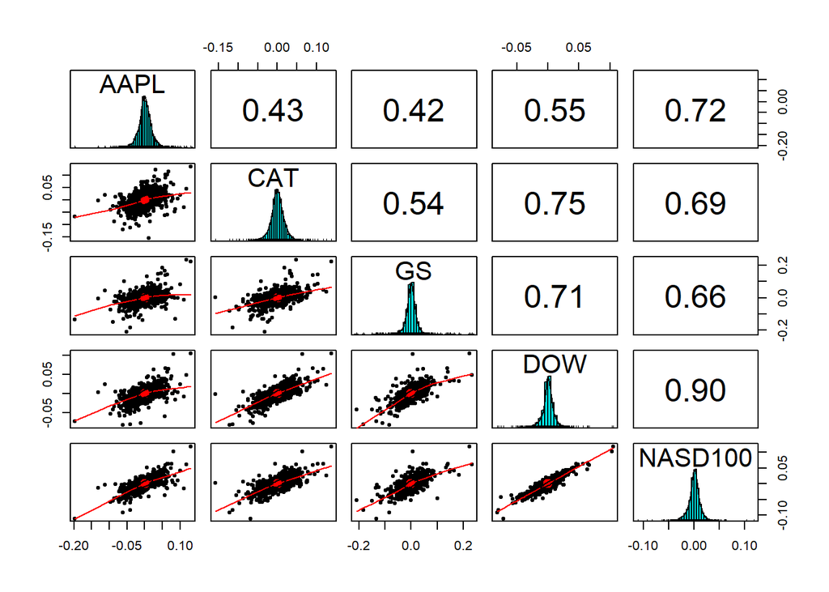

```r
pairs.panels(Returns2,breaks=50)
```

# Question 2

> [5 points] Based on the output from line 18, comment on the contemporaneous correlations between the Apple (AAPL) returns and the returns of the other four “assets”.

The correlations between AAPL and other four assets are 0.43 (vs CAT), 0.42 (vs GS), 0.55 (vs DOW), 0.72 (vs NASD100), respectively (all positive correlated). The AAPL has the highest correlation with NASD100, and the scatter plot between those two looks the most linear among the four.

# Question 3

> [10 points] Run lines 21 to 25, and submit the output.

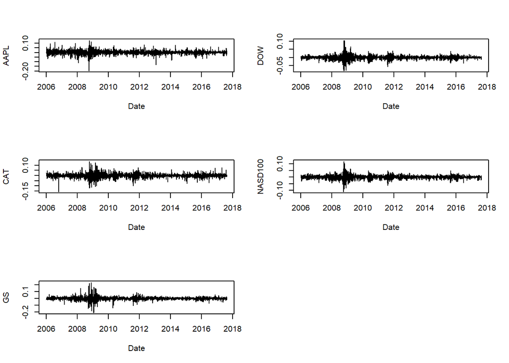

```r
par(mfcol=c(3,2))
for(i in 1:5) {
  plot(Returns$Date,Returns2[,i],type="l",xlab="Date",ylab=stock.names[i])
}
```

# Question 4

> [10 points] Based on the output from lines 21 to 25, and is there evidence of volatility clustering? When did the most pronounced volatility occur? Do you have an explanation for this timing?

There are multiple evidence of volatility clustering, with different size. The largest one for all the five assets occurred at the end of 2008, which was the global financial crisis.

# Question 5

> [10 points] Run lines 26 to 31, and submit the output.

```r
library(knitr)
n=getOption("digits")
options(digits=3)
kable(cov(Returns2),digits=6)
```

|  | AAPL | CAT | GS | DOW | NASD100 |
| --- | --- | --- | --- | --- | --- |
| AAPL | 0.000427 | 0.000180 | 0.000210 | 0.000130 | 0.000200 |
| CAT | 0.000180 | 0.000414 | 0.000265 | 0.000175 | 0.000188 |
| GS | 0.000210 | 0.000265 | 0.000580 | 0.000196 | 0.000213 |
| DOW | 0.000130 | 0.000175 | 0.000196 | 0.000130 | 0.000137 |
| NASD100 | 0.000200 | 0.000188 | 0.000213 | 0.000137 | 0.000180 |

```r
kable(cor(Returns2))
```

|  | AAPL | CAT | GS | DOW | NASD100 |
| --- | --- | --- | --- | --- | --- |
| AAPL | 1.000 | 0.428 | 0.423 | 0.552 | 0.721 |
| CAT | 0.428 | 1.000 | 0.541 | 0.752 | 0.687 |
| GS | 0.423 | 0.541 | 1.000 | 0.714 | 0.658 |
| DOW | 0.552 | 0.752 | 0.714 | 1.000 | 0.896 |
| NASD100 | 0.721 | 0.687 | 0.658 | 0.896 | 1.000 |

```r
colMeans(Returns2)
```

```
##     AAPL      CAT       GS      DOW  NASD100
## 0.000956 0.000342 0.000232 0.000236 0.000423
```

```r
options(digits=n)
```

# Question 6

> [5 points] Based on the output from line 30, what is the mean of the returns for Caterpillar index (CAT)?

```r
colMeans(Returns2)["CAT"]
```

```
##          CAT
## 0.0003416863
```

# Question 7

> [5 points] Based on the output from line 28, what is the variance of the returns for Goldman Sachs (GS)?

```r
cov(Returns2)["GS","GS"]
```

```
## [1] 0.0005798905
```

# Question 8

> [5 points] Based on the output from line 29, what is the correlation between the returns for the Dow Jones Industrial index and the returns of the NASDAQ 100 index?

```r
cor(Returns2)["DOW","NASD100"]
```

```
## [1] 0.8959862
```

# Question 9

> [10 points] Adapt and run lines 37 to 39 for Caterpillar (CAT), and submit the output.

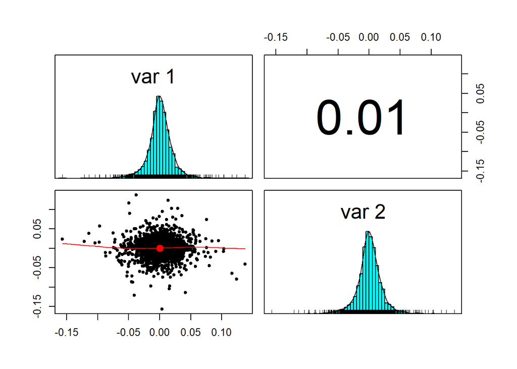

```r
ret.CAT=Returns$CAT
n.CAT=length(ret.CAT)
pairs.panels(cbind(ret.CAT[-n.CAT],ret.CAT[-1]),breaks=50)
```

# Question 10

> [5 points] Based on the output from lines 37 to 39, is there any evidence of serial correlation in the returns for Caterpillar (CAT)?

No, there is no evidence of serial correlation (autocorrelation) from either the scatter plot or the correlation value.

# Question 11

> [10 points] Suppose that daily log returns for an asset are independent and normally distributed with mean $\mu=0.004$ and standard deviation $\sigma=0.012$. If the initial value of the asset is $P_0=\$100,000$, what is the probability that the value of the asset is at least $\$108,000$ after 16 days, i.e., what is $P(P_{16}\geq\$108,000)$?

```r
1-pnorm(log(108000/100000),mean=0.004*16,sd=0.012*sqrt(16))
```

```
## [1] 0.3935718
```

# Question 12

> [15 points] Suppose that daily log returns for an asset are independent and normally distributed with mean $\mu=0.004$ and standard deviation $\sigma=0.012$. If the initial value of the asset is $\$100,000$, what is the probability that the value of the asset is at least $\$108,000$ during the next 30 days, i.e., what is the probability that at least one of $P_1,P_2,\cdots,P_{30}$ is at least $\$108,000$? Adapt lines 40 to 61 to simulate the probability. Provide your code. Use a simulation size of 250,000, and set the seed for random number generation to 8765. Give your estimate of the probability and a 99% confidence interval for the probability.

```r
#t1=proc.time()
set.seed(8765)
niter=250000
ind=matrix(nrow=niter,ncol=1)
for (i in 1:niter) {
  logR=rnorm(30,mean=0.004,sd=0.012)
  cumR=cumsum(logR)
  logP=log(100000)+cumR
  ind[i]=(max(logP)>=log(108000))
}
estProb=mean(ind)
se=sqrt(estProb*(1-estProb)/niter)
UpperCL=estProb+qnorm(0.995)*se
LowerCL=estProb+qnorm(0.005)*se

estProb
```

```
## [1] 0.812808
```

```r
#se
UpperCL
```

```
## [1] 0.8148175
```

```r
LowerCL
```

```
## [1] 0.8107985
```

```r
#t2=proc.time()
#t2-t1
```

The estimate of the probability is 0.812808, and the confidence interval for the probability is (0.8107985, 0.8148175).

# Code

```
01 Returns = read.csv("returns.csv")
02 names(Returns)
03 class(Returns$Date)
04 Returns$Date = as.Date(Returns$Date, format="%m/%d/%Y")
05 class(Returns$Date)
06 head(Returns,n=5)
07 tail(Returns)
08 mode(Returns)
09 class(Returns)
10 summary(Returns)
11 str(Returns)
12 stock.names=c("AAPL", "CAT", "GS", "DOW", "NASD100")
13 Returns2 = Returns[ ,stock.names]
14 plot(Returns2)
15 plot(as.ts(Returns2))
```

[output cut: 46 more lines]